# Practical Machine Learning Course Project

Omar Linares

6/3/2021

BACKGROUND Using devices such as Jawbone Up, Nike FuelBand, and Fitbit it is now possible to collect a large amount of data about personal activity relatively inexpensively. These type of devices are part of the quantified self movement – a group of enthusiasts who take measurements about themselves regularly to improve their health, to find patterns in their behavior, or because they are tech geeks. One thing that people regularly do is quantify how much of a particular activity they do, but they rarely quantify how well they do it. In this project, your goal will be to use data from accelerometers on the belt, forearm, arm, and dumbell of 6 participants. They were asked to perform barbell lifts correctly and incorrectly in 5 different ways.

```r
library(ggplot2);
library(caret);
library(randomForest);
library(rattle)
```

The first step was to import the data to R, and then delete the columns with the majority of Na`s

```r
trainingset <- read.csv("pml-training.csv", na.strings=c("NA","#DIV/0!", ""))
testingset <- read.csv("pml-testing.csv", na.strings=c("NA","#DIV/0!", ""))
trainingset<-trainingset[,colSums(is.na(trainingset)) == 0]
testingset <-testingset[,colSums(is.na(testingset)) == 0]
trainingset   <-trainingset[,-c(1:7)]
testingset <-testingset[,-c(1:7)]
```

The next step was to create the data partition

```r
train <- createDataPartition(y=trainingset$classe, p=0.75, list=FALSE)
TrainS <- trainingset[train, ]
TestS <- trainingset[-train, ]
```

The first method I used was the “Decision Tree”

```r
modFit<-train(classe~.,method="rpart",data=TrainS)
print(modFit$finalModel)
```

```
## n= 14718
##
## node), split, n, loss, yval, (yprob)
##       * denotes terminal node
##
##  1) root 14718 10533 A (0.28 0.19 0.17 0.16 0.18)
##    2) roll_belt< 130.5 13489  9312 A (0.31 0.21 0.19 0.18 0.11)
##      4) pitch_forearm< -33.95 1196     8 A (0.99 0.0067 0 0 0) *
##      5) pitch_forearm>=-33.95 12293  9304 A (0.24 0.23 0.21 0.2 0.12)
##       10) magnet_dumbbell_y< 436.5 10347  7428 A (0.28 0.18 0.24 0.19 0.11)
##         20) roll_forearm< 123.5 6464  3831 A (0.41 0.18 0.19 0.17 0.062) *
##         21) roll_forearm>=123.5 3883  2599 C (0.074 0.18 0.33 0.23 0.18) *
##       11) magnet_dumbbell_y>=436.5 1946   944 B (0.036 0.51 0.04 0.22 0.19) *
##    3) roll_belt>=130.5 1229     8 E (0.0065 0 0 0 0.99) *
```

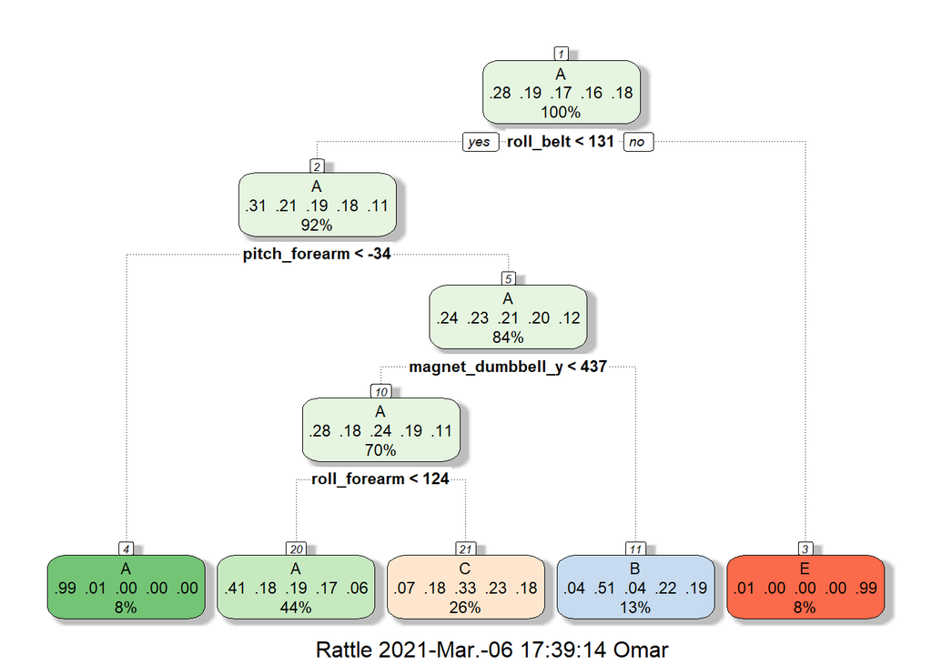

```r
fancyRpartPlot(modFit$finalModel)
```

```r
modFit
```

```
## CART
##
## 14718 samples
##    52 predictor
##     5 classes: 'A', 'B', 'C', 'D', 'E'
##
## No pre-processing
## Resampling: Bootstrapped (25 reps)
## Summary of sample sizes: 14718, 14718, 14718, 14718, 14718, 14718, ...
## Resampling results across tuning parameters:
##
##   cp          Accuracy   Kappa
##   0.03379854  0.5045457  0.35338061
##   0.06107788  0.4172123  0.21114295
##   0.11516187  0.3320048  0.07329025
##
## Accuracy was used to select the optimal model using the largest value.
## The final value used for the model was cp = 0.03379854.
```

```r
pred<-predict(modFit,newdata=TestS)
TestS$predRight<-pred==TestS$classe
table(pred,TestS$classe)
```

```
##
## pred    A    B    C    D    E
##    A 1248  411  381  363  123
##    B   25  300   31  158  121
##    C  116  238  443  283  247
##    D    0    0    0    0    0
##    E    6    0    0    0  410
```

After these results i create a new model by using Random Forest

```r
set.seed(2021)
modelfit2 <- train(classe ~ ., method = "ranger", data = TrainS)
modelfit2
```

```
## Random Forest
##
## 14718 samples
##    52 predictor
##     5 classes: 'A', 'B', 'C', 'D', 'E'
##
## No pre-processing
## Resampling: Bootstrapped (25 reps)
## Summary of sample sizes: 14718, 14718, 14718, 14718, 14718, 14718, ...
## Resampling results across tuning parameters:
##
##   mtry  splitrule   Accuracy   Kappa
##    2    gini        0.9901929  0.9875890
##    2    extratrees  0.9884970  0.9854428
##   27    gini        0.9898291  0.9871285
##   27    extratrees  0.9932961  0.9915171
##   52    gini        0.9804261  0.9752285
##   52    extratrees  0.9936786  0.9920013
##
## Tuning parameter 'min.node.size' was held constant at a value of 1
## Accuracy was used to select the optimal model using the largest value.
## The final values used for the model were mtry = 52, splitrule = extratrees
##  and min.node.size = 1.
```

The model seems to be pretty more accurate so we try to predict the classe of the TestSet

```r
pred<-predict(modelfit2,TestS)
TestS$predRight<-pred==TestS$classe
```

we create the predictions and then create a table comparing the prediction VS the actual classe of the observations

```r
table(pred,TestS$classe)
```

```
##
## pred    A    B    C    D    E
##    A 1394    2    0    0    0
##    B    1  946    6    0    0
##    C    0    1  849    3    0
##    D    0    0    0  800    1
##    E    0    0    0    1  900
```

As we can see there are a few miss classifications but in proportion to the ones the model correctly predicted the errors are really small.

Comparing these two models the decision seems to be obvious , the RANDOM FOREST model is the one we will use to Find the classe on the TEST data as it is the one with the highest accuracy.

Using the TEST data set we will now predict the classe variable using the Random Forest model in order to get the best accuracy possible.

```r
final<-predict(modelfit2,testingset)
final
```

```
##  [1] B A B A A E D B A A B C B A E E A B B B
## Levels: A B C D E
```

After seeing these result this would be all regarding the project about prediction.